# 326.212 Final Project: Part 3 - Q1

## 2020-10451 Baek Dae Hyun

## Part 3 - Q1

### [문제 1]

```r
korea_shp <- st_read("./data/SIG_202005/SIG.shp")
```

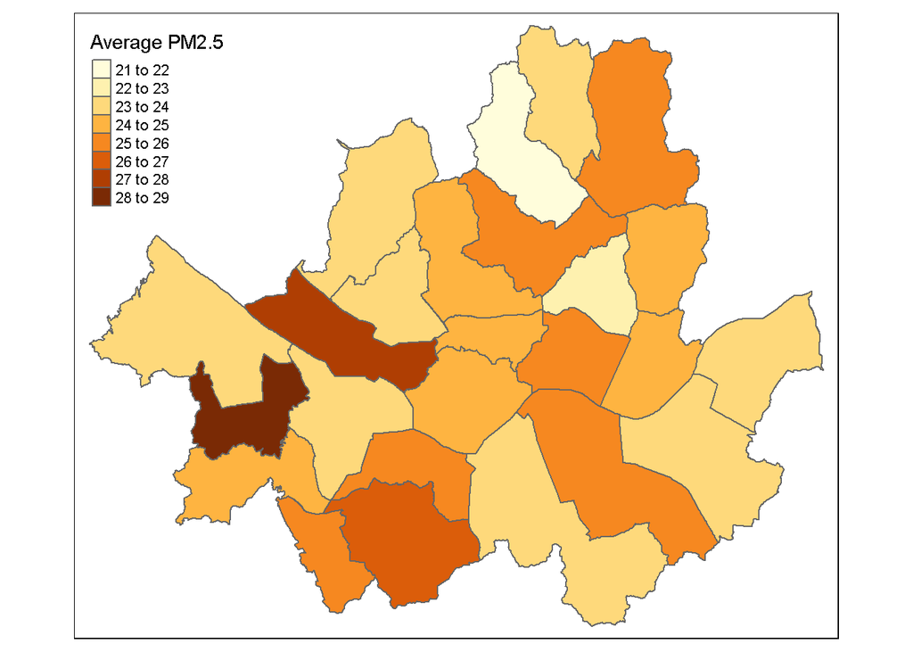

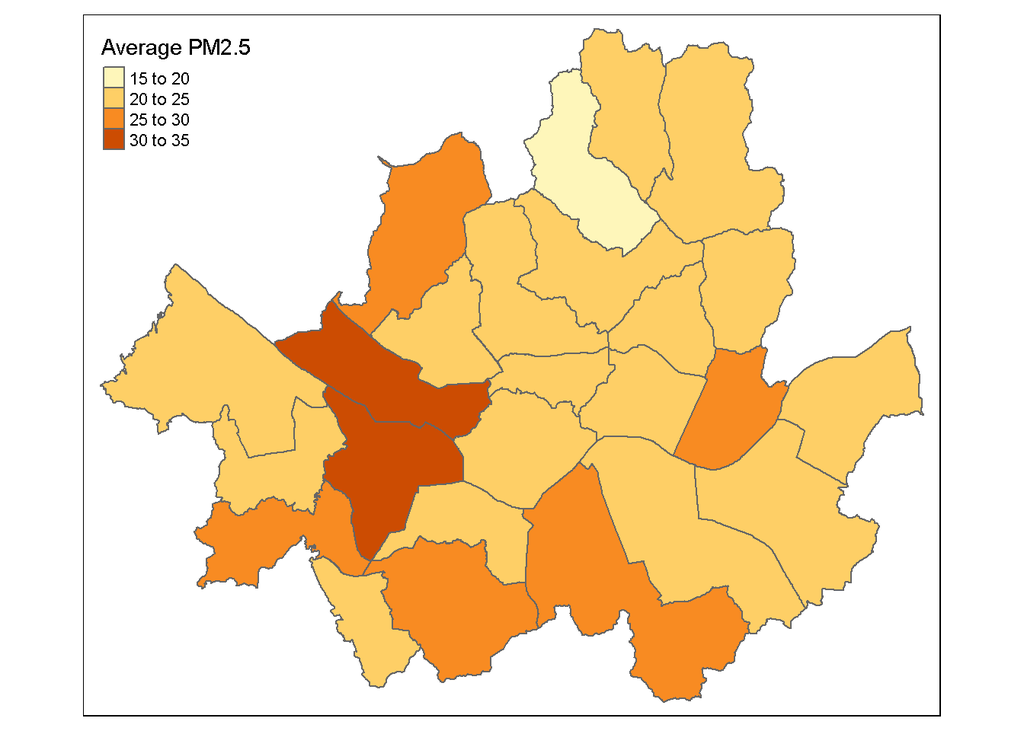

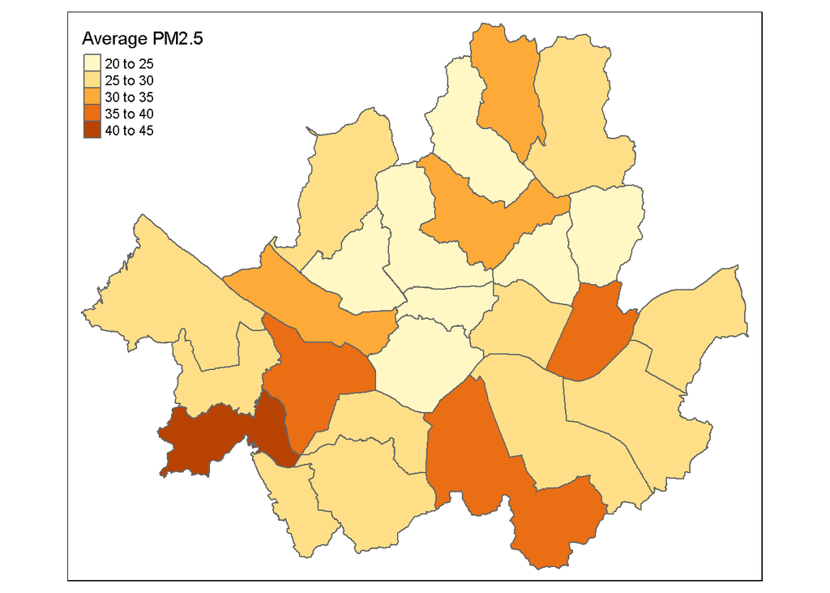

```r
korea_shp$SIG_KOR_NM <- iconv(korea_shp$SIG_KOR_NM, from = "CP949", to = "UTF-8",
                              sub = NA, mark = TRUE, toRaw = FALSE)
seoul_shp <- korea_shp %>% filter(str_detect(SIG_CD, "^11"))

data.spread2<-data%>%
  dplyr::select(Measurement.date,Station.name.district.,Item.name,Average.value)%>% #select only data district, item, average value
  tidyr::spread(key="Item.name",value="Average.value")%>% #spread data with key = Item name, value = Average value
  filter(!is.na(CO),!is.na(SO2),!is.na(PM2.5),!is.na(PM10),!is.na(NO2),!is.na(O3))%>% #remove all rows that has NA
  mutate(Year=year(parse_datetime(as.character(Measurement.date))),
         Month=month(parse_datetime(as.character(Measurement.date)))) #add date(Year, Month) columns


#summarise Average PM2.5, yearly
PM2.5<-data.spread2%>%
            group_by(Year)%>%
            group_by(Station.name.district., .add=TRUE)%>%
            summarise(
              "Average PM2.5"=mean(PM2.5)
            )%>%
            rename(SIG_ENG_NM=Station.name.district.) #rename in order to join with seoul_shp

sapply(c(2017,2018,2019),function (x){
  map_seoul_PM2.5<-seoul_shp%>%
    left_join(PM2.5)%>%
    filter(Year==x)%>%
    tm_shape() + tm_fill(col="Average PM2.5") + tm_borders()
    print(map_seoul_PM2.5)
    return (NULL)
})
```

분석을 위해 날짜(시각)과 지역별 오염물질의 양을 데이터로 하는 데이터프레임을 spread로 구현한다. 이는 Part 2에서 한 방법과 매우 유사하며, 여기서 차이점은 Part 2와 달리 오염물질로만 구성된 열에 추가적으로 Year과 Month 열을 추가했다는 것이다. 코드 간소화를 위해 sapply() 안에 문제에서 요구하는 지도를 print하는 함수를 정의하고 연도에 해당하는 벡터를 넣어 자동으로 print 결과가 출력되게 하였다. 연도별, 지역별 PM2.5 농도의 평균을 계산, Average PM2.5라는 변수를 생성, Average PM2.5과 Year 변수를 seoul_shp에 함께 추가(left_join)한다. 그리고 sapply에 연도를 인자로 넣고, 함수 내에 filter를 연도에 따라 취하도록 하면 코드 한번에 동시에 3개의 plot이 그려지게 된다. 왼쪽부터 차례로 2017년, 2018년, 2019년 자료이다. 2017년 자료를 보면 색깔이 달라지게 되는 구간 간격이 1인 한편 2018년 2019년은 5이다. 2017년 자료에서 가장 색이 연한 곳의 Average PM2.5는 21~22, 가장 진한 곳은 28~29로 최대 차이가 8이지만 2018년 자료에서는 최대 차이가 15~20에서 30~35로 20이나 차이가 난다. 따라서 2017년 자료는 지역별 Average PM2.5 차이가 작은 편이고, 그것의 큰 차이를 보려면 2018년도와 2019년도 자료에 주목하여야 한다. 2018년도와 2019년도 자료를 보면 5시 방향의 큰 덩어리 , 그리고 지도 중심부로부터 7시 방향으로 이어지는 인접한 3개의 덩어리가 공통적으로 진한 색을 보였다. 그러므로 서울 중심부에서 약간 서쪽에 위치한 인접한 2개의 구, 그리고 그것 중 하나와 인접해 있는 7시 방향, 마지막으로 5시 방향에서 PM2.5의 농도가 높게 나타났다고 볼 수 있다.

### [문제 2]

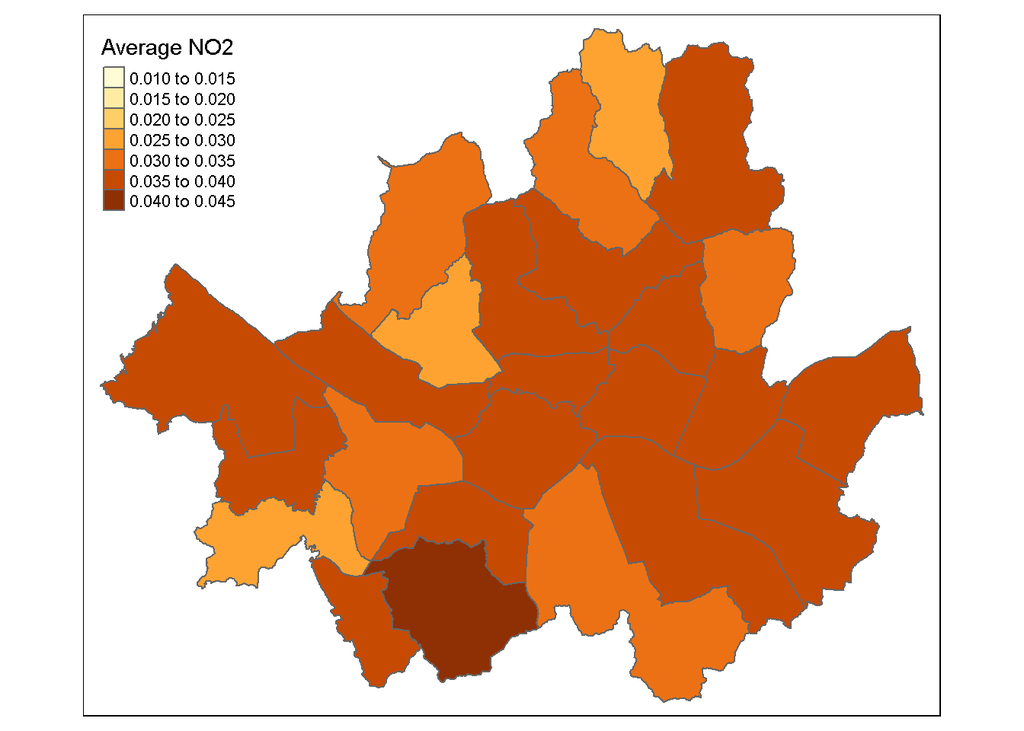

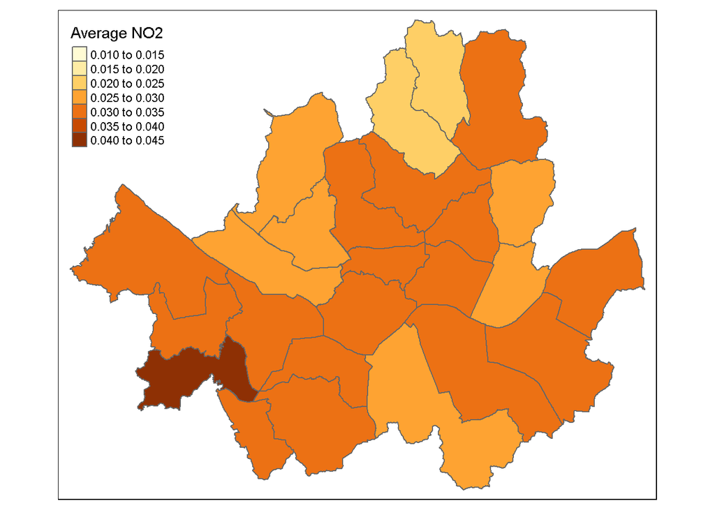

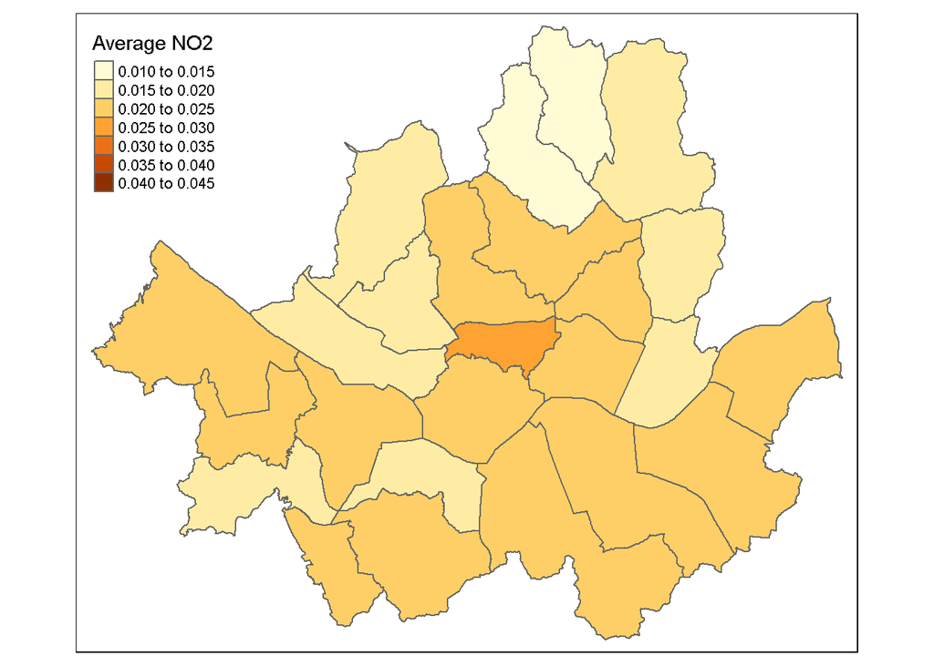

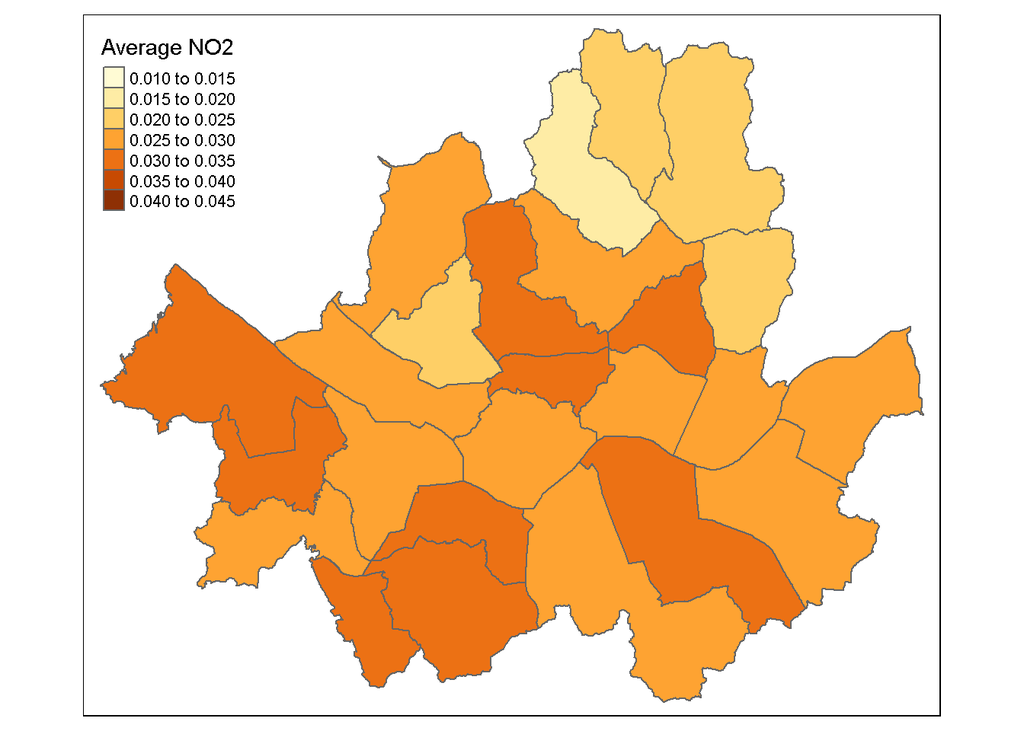

```r
#a function that returns Season with input=Month.
Season<-function(month){
  s = month %/% 3
  if (!(month %in% c(1:12))){
    print("Not available number")
  }
  else if (s==0||s==4){
    return("Winter")
  }
  else if (s==1){
    return("Spring")
  }
  else if (s==2){
    return("Summer")
  }
  else return("Fall")
}

#make df for printing
NO2<-data.spread2%>%
  mutate(season=sapply(Month,Season))%>%
  group_by(season)%>%
  group_by(Station.name.district., .add=TRUE)%>%
  summarise(
    "Average NO2"=mean(NO2)
  )%>%
  rename(SIG_ENG_NM=Station.name.district.)

#print
sapply(c("Winter","Spring","Summer","Fall"),function (x){
  map_seoul_NO2<-seoul_shp%>%
    left_join(NO2)%>%
    filter(season==x)%>%
    tm_shape() + tm_fill(breaks = seq(0.01, 0.045, by = 0.005), col="Average NO2") + tm_borders()
    print(map_seoul_NO2)
    return (NULL)
})
```